# PAC2_JordiSallerasAlabau

[figure not shown]

M2.975 · Deep Learning · PEC2

2021-2 · Màster universitari en Ciència de dades (Data science)

Estudis d'Informàtica, Multimèdia i Telecomunicació

# PAC2: Xarxes Neuronals Convolucionals amb KERAS

Al llarg d'aquesta pràctica implementarem diversos models de xarxes neuronals per classificar les imatges de la base de dades [CIFAR10](https://www.cs.toronto.edu/~kriz/cifar.html).

La base de dades CIFAR10 està formada per imatges en color de dimensions 32x32 píxels que pertanyen a 10 classes:

- airplane (label 0)
- automobile (label 1)
- bird (label 2)
- cat (label 3)
- deer (label 4)
- dog (label 5)
- frog (label 6)
- horse (label 7)
- xip (label 8)
- truck (label 9)

Aquesta base de dades està formada per 60.000 registres que es divideixen en 2 conjunts: 50.000 imatges per al conjunt d'entrenament i 10.000 imatges per al conjunt de test.

A l'exercici durem a terme la tasca de construir diversos models amb l'objectiu d'aconseguir la major precisió en fer la classificació de les imatges. Per això implementarem i analitzarem els models següents:

1. Una xarxa neuronal artificial completament connectada
2. Una xarxa neuronal convolucional d'una capa
3. Una xarxa neuronal convolucional profunda

 En tots els casos es farà servir la llibreria Keras amb Tensorflow per a la implementació del model, la compilació i l'entrenament.

Finalment, farem una predicció de les imatges amb el millor model implementat.

 **Important: Cadascun dels exercicis pot suposar diversos minuts d'execució, per la qual cosa el lliurament s'ha de fer en format notebook i en format html on es vegi el codi i els resultats i comentaris de cada exercici. Per exportar el notebook a html es pot fer des del menú File $\to$ Download as $\to$ HTML.**

## 1. Descàrrega, anàlisi i preprocessament de les dades (1,5 punts)

### 1.1 Descàrrega de les dades

Comencem important alguns paquets per a la realització de la pràctica i procedim a descarregar el dataset.

```python
import numpy as np
from tensorflow import keras
from keras.datasets import cifar10
from tensorflow.keras.utils import to_categorical
from keras.models import Sequential
from keras.layers import Dense, Conv2D, Flatten, Activation, Dropout, MaxPooling2D
from tensorflow.keras.optimizers import Adam, SGD, Adadelta, Adagrad
import matplotlib.pyplot as plt
import time
from sklearn.metrics import confusion_matrix, classification_report
import seaborn as sns
```

```python
# Descarrega el dataset CIFAR10 i fa la partició train/test
(X_train, y_train), (X_test, y_test) = cifar10.load_data()
```

```
Downloading data from https://www.cs.toronto.edu/~kriz/cifar-10-python.tar.gz
```

### 1.2 Anàlisi de les dades

**Exercici [0,5 pts.]:** Representar la dimensió de les variables X_train, y_train, X_test i y_test. Mostra les imatges dels primers 10 registres del conjunt X_train juntament amb les etiquetes en format text. **Nota**: Com que les imatges son de mida petita (32x32) es recomana escalar-les a l'hora de representar-les.

```
Train: X=(50000, 32, 32, 3), y=(50000, 1)
Test: X=(10000, 32, 32, 3), y=(10000, 1)
```

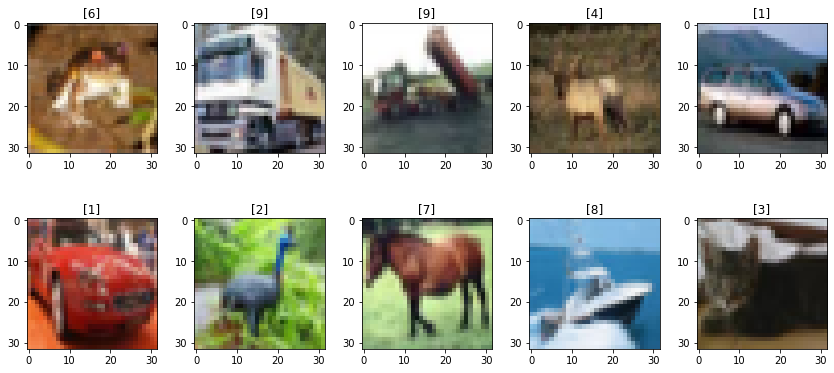

```python
print('Train: X=%s, y=%s' % (X_train.shape, y_train.shape))
print('Test: X=%s, y=%s' % (X_test.shape, y_test.shape))

fig, axs = plt.subplots(2,5, figsize=(15, 6), facecolor='w', edgecolor='k')
fig.subplots_adjust(hspace = .5, wspace=.001)
axs = axs.ravel()
for i in range(10):
    axs[i].imshow(X_train[i])
    axs[i].set_title(y_train[i])
```

### 1.3 Pre-processament de les dades

Atès que les imatges son en color, les convertirem a escala de grisos per realitzar les primeres classificacions. Per això utilitzarem la funció `cvtColor` del paquet [OpenCV](https://pypi.org/project/opencv-python/) (cv2)

```python
import cv2

# Converteix X_train i X_test a escala de grisos
X_train_grey = np.array([cv2.cvtColor(image, cv2.COLOR_BGR2GRAY) for image in X_train])
X_test_grey = np.array([cv2.cvtColor(image, cv2.COLOR_BGR2GRAY) for image in X_test])
```

**Exercici [0,25 pts.]:** Representar la dimensió de les variables X_train_grey i X_test_grey. Mostra les imatges dels primers 10 registres del conjunt X_train_grey juntament amb les etiquetes en format text.

```
Train: X= (50000, 32, 32)
Test: X= (10000, 32, 32)
```

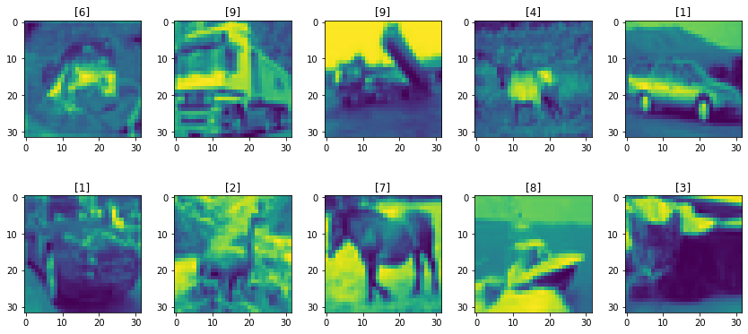

```python
# TODO
print('Train: X= ' + str(X_train_grey.shape))
print('Test: X= ' + str(X_test_grey.shape))

fig, axs = plt.subplots(2,5, figsize=(15, 6), facecolor='w', edgecolor='k')
fig.subplots_adjust(hspace = .5, wspace=.001)
axs = axs.ravel()
for i in range(10):
    axs[i].imshow(X_train_grey[i])
    axs[i].set_title(y_train[i])
```

El primer pas per entrenar una xarxa neuronal consisteix a preprocessar les dades d'entrenament i test perquè quadrin amb el format esperat per les entrades i sortides de la xarxa neuronal.

Començarem normalitzant les dades d'entrada perquè estiguin al rang [0,1] ja que, com podem veure a continuació, es tracta de valors sencers entre 0 i 255.

```python
print("Els valors del primer registre de X_train_grey són: {}".format(X_train_grey[0]))
```

```
Els valors del primer registre de X_train_grey són: [[ 62  45  47 ... 128 121 120]
 [ 20   0   7 ...  82  77  82]
 [ 23   6  24 ...  78  78  68]
 ...
 [152 123 125 ... 117  27  32]
 [131 104 115 ... 136  58  51]
 [139 123 130 ... 174 112  90]]
```

```python
# Determinar valors mínim i màxim
v_min = np.min(X_train_grey)
v_max = np.max(X_train_grey)
print("Els valors mínim i màxim són {} y {}.".format(v_min, v_max))
```

```
Els valors mínim i màxim són 0 y 255.
```

**Exercici [0,5 pts.]:** Normalitzar les dades d'entrada a la xarxa perquè estiguin compreses al rang [0,1]. Imprimir les dades del primer registre un cop s'ha dut a terme la normalització i tornar a comprovar els valors màxim i mínim.

```python
# TODO
# normalize to range 0-1
train_norm = X_train_grey / 255.0
test_norm = X_test_grey / 255.0
print("Els valors del primer registre de X_train_grey són: {}".format(train_norm[0]))

v_min = np.min(train_norm)
v_max = np.max(train_norm)
print("\nEls valors mínim i màxim són {} y {}.".format(v_min, v_max))
```

```
Els valors del primer registre de X_train_grey són: [[0.24313725 0.17647059 0.18431373 ... 0.50196078 0.4745098  0.47058824]
 [0.07843137 0.         0.02745098 ... 0.32156863 0.30196078 0.32156863]
 [0.09019608 0.02352941 0.09411765 ... 0.30588235 0.30588235 0.26666667]
 ...
 [0.59607843 0.48235294 0.49019608 ... 0.45882353 0.10588235 0.1254902 ]
 [0.51372549 0.40784314 0.45098039 ... 0.53333333 0.22745098 0.2       ]
 [0.54509804 0.48235294 0.50980392 ... 0.68235294 0.43921569 0.35294118]]

Els valors mínim i màxim són 0.0 y 1.0.
```

**Exercici [0,25 pts.]:** Codificar els valors de les etiquetes de sortida en un vector one-hot. Per exemple, el vector de sortida per a una imatge que conté un 5 seria: [0., 0., 0., 0., 0., 1., 0., 0., 0., 0.]. Comprovar el resultat imprimint-ne la dimensió i mostrant algun registre.

**Nota**: Es pot utilitzar la funció `to_categorical` de `tensorflow.keras.utils`.

```python
# TODO
trainY = to_categorical(y_train)
testY = to_categorical(y_test)

print('Train: y= ' + str(trainY.shape))
print('Test: y= ' + str(testY.shape))

print(trainY[0:5])
```

```
Train: y= (50000, 10)
Test: y= (10000, 10)
[[0. 0. 0. 0. 0. 0. 1. 0. 0. 0.]
 [0. 0. 0. 0. 0. 0. 0. 0. 0. 1.]
 [0. 0. 0. 0. 0. 0. 0. 0. 0. 1.]
 [0. 0. 0. 0. 1. 0. 0. 0. 0. 0.]
 [0. 1. 0. 0. 0. 0. 0. 0. 0. 0.]]
```

## 2. Xarxa Neuronal Artificial (ANN) completament connectada [2,5 punts]

A continuació implementarem una xarxa neuronal *feed-forward fully connected* i durem a terme l'entrenament i test sobre el dataset CIFAR.

### 2.1 Pre-processament de les dades

Atès que en una xarxa neuronal artificial les entrades són unidimensionals, la primera cosa que hem de fer és redimensionar les dades d'entrada (les imatges) per convertir-les en arrays d'una dimensió.

**Exercici [0,5 pts.]:** Modificar els conjunts X_train_grey i X_test_grey per a que els seus registres siguin arrays unidimensionals de dimensió 32x32 = 1024 dades. Comproveu el resultat imprimint les dimensions de les variables.

```python
# TODO
X_train_gflat = train_norm.reshape(50000,-1)
X_test_gflat = test_norm.reshape(10000,-1)

print("X_train_gflat shape: " + str(X_train_gflat.shape))
print("X_test_gflat shape: " + str(X_test_gflat.shape))
```

```
X_train_gflat shape: (50000, 1024)
X_test_gflat shape: (10000, 1024)
```

### 2.2 Creació del model

Farem servir el model `Sequential` de Keras

**Exercici [2 pts.]:** Implementa el següent model de xarxa neuronal artificial:

- Dissenya l'arquitectura per al model de classificació amb les característiques següents:
- 6 capes ocultes de 128 neurones.
- 3 capes de Dropout del 20% (rate=0,2) intercalades cada 2 capes denses.
- Funció d'activació de les capes intermèdies: ReLU.
- 1 capa de sortida amb les dimensions i la funció d'activació adequades per realitzar la classificació.
- Imprimeix el model per veure el nombre de paràmetres que cal entrenar.
- Compila el model amb la funció de pèrdua més adequada, l'optimitzador SGD, una velocitat d'aprenentatge de 0.01 i la mètrica Accuracy.
- Ajusta el model amb 100 èpoques i una mida del batch de 128. Mesura el temps d'entrenament.
- Mostra les gràfiques d'accuracy i loss. A cada gràfica cal visualitzar la corba d'entrenament i la de validació. NOTA: Es recomana fer una funció que imprimeixi les dues gràfiques per poder-la reutilitzar en propers apartats.
- Realitza l'avaluació del model per mostrar la pèrdua i la precisió final.

```python
# Crear el model ANN
# TODO
model = keras.models.Sequential([
    keras.layers.Dense(128, activation="relu", input_shape=[1024]),
    keras.layers.Dense(128, activation="relu"),
    keras.layers.Dropout(0.2),
    keras.layers.Dense(128, activation="relu"),
    keras.layers.Dense(128, activation="relu"),
    keras.layers.Dropout(0.2),
    keras.layers.Dense(128, activation="relu"),
    keras.layers.Dense(128, activation="relu"),
    keras.layers.Dropout(0.2),
    keras.layers.Dense(10, activation="softmax")
])

print(model.summary())
```

```
2022-04-10 12:51:07.765996: I tensorflow/stream_executor/cuda/cuda_gpu_executor.cc:937] successful NUMA node read from SysFS had negative value (-1), but there must be at least one NUMA node, so returning NUMA node zero
```

```
Model: "sequential"
_________________________________________________________________
Layer (type)                 Output Shape              Param #
=================================================================
dense (Dense)                (None, 128)               131200
_________________________________________________________________
dense_1 (Dense)              (None, 128)               16512
_________________________________________________________________
dropout (Dropout)            (None, 128)               0
_________________________________________________________________
dense_2 (Dense)              (None, 128)               16512
_________________________________________________________________
dense_3 (Dense)              (None, 128)               16512
_________________________________________________________________
dropout_1 (Dropout)          (None, 128)               0
_________________________________________________________________
dense_4 (Dense)              (None, 128)               16512
_________________________________________________________________
dense_5 (Dense)              (None, 128)               16512
_________________________________________________________________
dropout_2 (Dropout)          (None, 128)               0
_________________________________________________________________
dense_6 (Dense)              (None, 10)                1290
=================================================================
Total params: 215,050
Trainable params: 215,050
Non-trainable params: 0
_________________________________________________________________
None
```

[output not shown]

```python
# Compile
# TODO
model.compile(keras.optimizers.SGD(learning_rate=0.01),
              loss='categorical_crossentropy',
              metrics=['accuracy'])
```

```python
# Entrenar el model
# TODO
history = model.fit(X_train_gflat, trainY,
          validation_data = (X_test_gflat, testY),
          epochs=100,
          batch_size=128,
          verbose = 0)
```

```
2022-04-10 12:51:10.505784: I tensorflow/compiler/mlir/mlir_graph_optimization_pass.cc:185] None of the MLIR Optimization Passes are enabled (registered 2)
```

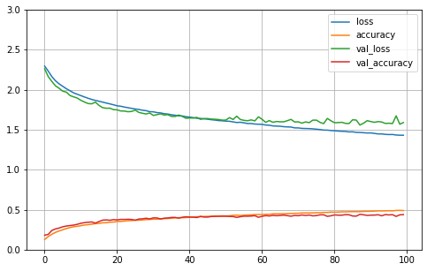

```python
# Plot del training loss i l'accuracy
#def plot_prediction(n_epochs, mfit):
    # TODO
import pandas as pd
pd.DataFrame(history.history).plot(figsize=(8, 5))
plt.grid(True)
plt.gca().set_ylim(0, 3) # set the vertical range to [0-1]
plt.show()
```

```python
# Resultats
# TODO
model.evaluate(X_test_gflat, testY)
```

```
[1.589406132698059, 0.43790000677108765]
```

## 3. Xarxa Neuronal Convolucional d'una capa [2.5 punts]

A continuació implementarem una xarxa neuronal convolucional d'una capa i farem l'entrenament i el test sobre el dataset CIFAR.

Es recomana, a partir d'aquest punt, fer l'entrenament en una màquina amb GPU (es pot activar en plataformes com Google Colab o Kaggle) per tal de reduir els temps d'entrenament.

### 3.1 Pre-processament de les dades

El primer pas per entrenar una xarxa neuronal consisteix a preprocessar les dades d'entrenament i test perquè quadrin amb les dimensions de l'entrada de la xarxa neuronal.

**Exercici [0,5 pts.]:** Ajusteu la mida de les dades d'entrenament i test perquè tinguin 4 dimensions (l'última dimensió ha de ser 1 per indicar que les imatges estan en escala de grisos).

**Nota**: Utilitzar el nombre de dades d'entrenament i test i la mida de les imatges.

```python
# TODO
X_train = np.expand_dims(train_norm, axis=3)
X_test = np.expand_dims(test_norm, axis=3)
y_train = trainY
y_test = testY

print("Train shape: {} \nTest shape: {}".format(X_train.shape,X_test.shape))
```

```
Train shape: (50000, 32, 32, 1)
Test shape: (10000, 32, 32, 1)
```

### 3.2 Creació del model

Es vol implementar el model `Sequential` de Keras amb les següents característiques:

- La primera capa que afegirem serà una capa convolucional amb les propietats següents:
  - Nombre de kernels (neurones) de la primera capa oculta: 64 neurones
  - Grandària dels kernels: 3x3
  - Activació dels kernels: ReLU
- A continuació, afegirem una capa Flatten per connectar la sortida de la capa convolucional amb l'entrada d'una capa densa.
- Finalment, afegirem una capa densa de sortida amb el nombre de neurones i funció d'activació adequades per dur a terme la classificació.

**Exercici [1,5 pts.]:** Construir el model segons els requeriments indicats.

A més:

- Imprimeix el model per veure el nombre de paràmetres que cal entrenar.
- Compila el model amb la funció de pèrdua més adequada, l'optimitzador ADAM i la mètrica Accuracy.
- Ajusta el model amb 20 èpoques i una mida del batch de 128. Mesura el temps d'entrenament.
- Mostra les gràfiques d'accuracy i loss. A cada gràfica cal visualitzar la corba d'entrenament i la de validació
- Realitza l'avaluació del model per mostrar la pèrdua i la precisió final.

```python
# Crear la CNN monocapa
# TODO
model = keras.models.Sequential([
    keras.layers.Conv2D(64, (3, 3), activation='relu',input_shape=(32, 32, 1)),
    keras.layers.Flatten(),
    keras.layers.Dense(10, activation="softmax"),
])

print(model.summary())
```

```
Model: "sequential"
_________________________________________________________________
Layer (type)                 Output Shape              Param #
=================================================================
conv2d (Conv2D)              (None, 30, 30, 64)        640
_________________________________________________________________
flatten (Flatten)            (None, 57600)             0
_________________________________________________________________
dense (Dense)                (None, 10)                576010
=================================================================
Total params: 576,650
Trainable params: 576,650
Non-trainable params: 0
_________________________________________________________________
None
```

```
2022-04-10 13:16:41.613836: I tensorflow/core/common_runtime/process_util.cc:146] Creating new thread pool with default inter op setting: 2. Tune using inter_op_parallelism_threads for best performance.
```

```python
# Compile
# TODO
model.compile(keras.optimizers.Adam(),
              loss='categorical_crossentropy',
              metrics=['accuracy'])
```

```python
%%time
# Entrenament del model
# TODO

history = model.fit(X_train, y_train,
          validation_data = (X_test, y_test),
          epochs=20,
          batch_size=128,
          verbose = 0)
```

```
2022-04-10 12:53:35.962438: I tensorflow/stream_executor/cuda/cuda_dnn.cc:369] Loaded cuDNN version 8005
```

```
CPU times: user 28.1 s, sys: 4.08 s, total: 32.1 s
Wall time: 41.7 s
```

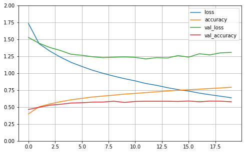

```python
# Resultats
# TODO
pd.DataFrame(history.history).plot(figsize=(8, 5))
plt.grid(True)
plt.gca().set_ylim(0, 2) # set the vertical range to [0-1]
plt.show()
```

```python
model.evaluate(X_test, y_test)
```

```
[1.307800531387329, 0.5788999795913696]
```

### 3.3 GPU vs CPU

**Exercici [0,5 pts.]:** Tornar a entrenar el model des de zero en un entorn sense GPU (només amb la CPU) i compara els temps d'entrenament. Comenta els resultats.

```python
%%time
# Entrenament del model sense GPU
# TODO
history = model.fit(X_train, y_train,
          validation_data = (X_test, y_test),
          epochs=20,
          batch_size=128,
          verbose = 0)
```

```
2022-04-10 13:16:49.158866: I tensorflow/compiler/mlir/mlir_graph_optimization_pass.cc:185] None of the MLIR Optimization Passes are enabled (registered 2)
```

```
CPU times: user 12min 30s, sys: 8.32 s, total: 12min 38s
Wall time: 3min 41s
```

Veiem que el mateix model entrenat només amb CPU presenta uns temps d'entrenament bastant superiors al que hem vist amb la GPU. Considerant que estem entrenant amb només 20 epochs, comprovem que sería bastant inviable utilitzar la CPU per a models grans.

## 4. Deep CNN amb Maxpooling i Dropout [2 punts]

A l'exercici anterior hem implementat una xarxa convolucional d'una sola capa. Ara implementarem una xarxa neuronal convolucional profunda i veurem com això es tradueix en un millor rendiment en els resultats.

### 4.1 Creació del model

En aquest cas tornarem a utilitzar el model `Sequential` de Keras que constarà de:

- Dues capes convolucionals de 32 kernels cadascuna de mida 3x3
- Una capa de MaxPooling amb una mida de 2x2
- Una capa de Dropout amb un rate=0.2
- Dues capes convolucionals de 64 kernels cadascuna de mida 3x3
- Una capa de MaxPooling amb una mida de 2x2
- Una capa de Dropout amb un rate=0.2
- Dues capes convolucionals de 128 kernels cadascuna de mida 3x3
- Una capa de MaxPooling amb una mida de 2x2
- Una capa de Dropout amb un rate=0.2
- Totes les capes convolucionals amb funció d'activació ReLU i padding = same
- Una capa Flatten
- Una capa densa amb 128 neurones i funció d'activació ReLU
- Una capa de Dropout amb un rate=0.2
- Una capa densa de sortida amb el nombre de neurones i la funció d'activació necessàries per dur a terme la classificació

**Exercici [1,5 pts.]:** Construir el model segons els requeriments indicats, a més:

- Imprimeix el model per veure el nombre de paràmetres que cal entrenar.
- Compila el model amb la funció de pèrdua més adequada, l'optimitzador SGD (amb learning rate de 0.001 i momentum de 0.9) i la mètrica Accuracy.
- Ajusta el model amb 150 èpoques i una mida del batch de 128. Mesura el temps d'entrenament.
- Mostra les gràfiques d'accuracy i loss. A cada gràfica cal visualitzar la corba d'entrenament i la de validació
- Realitza l'avaluació del model per mostrar la pèrdua i la precisió final.

```python
# Crear la CNN profunda
# TODO

model = keras.models.Sequential([
    keras.layers.Conv2D(32, (3, 3), activation='relu', padding = 'same', input_shape=(32, 32, 1)),
    keras.layers.Conv2D(32, (3, 3), activation='relu', padding = 'same'),
    keras.layers.MaxPooling2D((2, 2)),
    keras.layers.Dropout(0.2),

    keras.layers.Conv2D(64, (3, 3), activation='relu', padding = 'same'),
    keras.layers.Conv2D(64, (3, 3), activation='relu', padding = 'same'),
    keras.layers.MaxPooling2D((2, 2)),
    keras.layers.Dropout(0.2),

    keras.layers.Conv2D(128, (3, 3), activation='relu', padding = 'same'),
    keras.layers.Conv2D(128, (3, 3), activation='relu', padding = 'same'),
    keras.layers.MaxPooling2D((2, 2)),
    keras.layers.Dropout(0.2),

    keras.layers.Dense(128, activation='relu'),
    keras.layers.Dropout(0.2),

    keras.layers.Flatten(),
    keras.layers.Dense(10, activation="softmax"),
])

print(model.summary())
```

```
Model: "sequential_2"
_________________________________________________________________
Layer (type)                 Output Shape              Param #
=================================================================
conv2d_1 (Conv2D)            (None, 32, 32, 32)        320
_________________________________________________________________
conv2d_2 (Conv2D)            (None, 32, 32, 32)        9248
_________________________________________________________________
max_pooling2d (MaxPooling2D) (None, 16, 16, 32)        0
_________________________________________________________________
dropout_3 (Dropout)          (None, 16, 16, 32)        0
_________________________________________________________________
conv2d_3 (Conv2D)            (None, 16, 16, 64)        18496
_________________________________________________________________
conv2d_4 (Conv2D)            (None, 16, 16, 64)        36928
_________________________________________________________________
max_pooling2d_1 (MaxPooling2 (None, 8, 8, 64)          0
_________________________________________________________________
dropout_4 (Dropout)          (None, 8, 8, 64)          0
_________________________________________________________________
conv2d_5 (Conv2D)            (None, 8, 8, 128)         73856
_________________________________________________________________
conv2d_6 (Conv2D)            (None, 8, 8, 128)         147584
_________________________________________________________________
max_pooling2d_2 (MaxPooling2 (None, 4, 4, 128)         0
_________________________________________________________________
dropout_5 (Dropout)          (None, 4, 4, 128)         0
_________________________________________________________________
dense_8 (Dense)              (None, 4, 4, 128)         16512
_________________________________________________________________
dropout_6 (Dropout)          (None, 4, 4, 128)         0
_________________________________________________________________
flatten_1 (Flatten)          (None, 2048)              0
_________________________________________________________________
dense_9 (Dense)              (None, 10)                20490
=================================================================
Total params: 323,434
Trainable params: 323,434
Non-trainable params: 0
_________________________________________________________________
None
```

```python
# Compile
# TODO
model.compile(keras.optimizers.SGD(learning_rate=0.001, momentum=0.9),
              loss='categorical_crossentropy',
              metrics=['accuracy'])
```

```python
%%time
# Entrenament del model
# TODO
history = model.fit(X_train, y_train,
          validation_data = (X_test, y_test),
          epochs=150,
          batch_size=128,
          verbose = 0)
```

```
CPU times: user 6min 26s, sys: 40.2 s, total: 7min 6s
Wall time: 8min
```

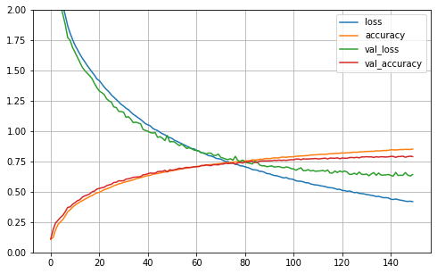

```python
# Resultats
# TODO
pd.DataFrame(history.history).plot(figsize=(8, 5))
plt.grid(True)
plt.gca().set_ylim(0, 2) # set the vertical range to [0-1]
plt.show()
```

```python
model.evaluate(X_test, y_test)
```

```
[0.6418136954307556, 0.7900000214576721]
```

### 4.2 CNN amb imatges en color

Finalment estudiarem la influència del color de les imatges en la *performance* de la classificació.

Per això utilitzarem una xarxa convolucional amb la mateixa estructura de la xarxa de l'apartat anterior però canviant la capa d'entrada perquè puguem introduir les imatges originals en color, arrays de dimensió (32, 32, 3).

**Exercici [0,5 pts]:** Tornar a fer l'exercici anterior però modificant la capa d'entrada per poder utilitzar el conjunt de dades original, de mida (50000, 32, 32, 3) per al conjunt de train i (10000, 32, 32, 3) per al conjunt de test. Influeix el color de les imatges en el resultat de la classificació? Comenteu el resultat.

**Nota**: Recordeu normalitzar les imatges per a que els seus valors estiguin entre 0 i 1.

```
Train: X=(50000, 32, 32, 3), y=(50000, 1)
Test: X=(10000, 32, 32, 3), y=(10000, 1)
```

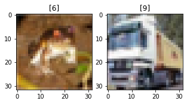

```python
(X_train, y_train), (X_test, y_test) = cifar10.load_data()
print('Train: X=%s, y=%s' % (X_train.shape, y_train.shape))
print('Test: X=%s, y=%s' % (X_test.shape, y_test.shape))

fig, axs = plt.subplots(1,2, figsize=(5, 5), facecolor='w', edgecolor='k')
fig.subplots_adjust(hspace = .5, wspace=.2)
axs = axs.ravel()
for i in range(2):
    axs[i].imshow(X_train[i])
    axs[i].set_title(y_train[i])
```

```python
# Normalitzar
# TODO

# normalize to range 0-1
X_train = X_train / 255.0
X_test = X_test / 255.0

y_train = to_categorical(y_train)
y_test = to_categorical(y_test)
```

```python
# Crear la CNN profunda
# TODO

model = keras.models.Sequential([
    keras.layers.Conv2D(32, (3, 3), activation='relu', padding = 'same', input_shape=(32, 32, 3)),
    keras.layers.Conv2D(32, (3, 3), activation='relu', padding = 'same'),
    keras.layers.MaxPooling2D((2, 2)),
    keras.layers.Dropout(0.2),

    keras.layers.Conv2D(64, (3, 3), activation='relu', padding = 'same'),
    keras.layers.Conv2D(64, (3, 3), activation='relu', padding = 'same'),
    keras.layers.MaxPooling2D((2, 2)),
    keras.layers.Dropout(0.2),

    keras.layers.Conv2D(128, (3, 3), activation='relu', padding = 'same'),
    keras.layers.Conv2D(128, (3, 3), activation='relu', padding = 'same'),
    keras.layers.MaxPooling2D((2, 2)),
    keras.layers.Dropout(0.2),

    keras.layers.Dense(128, activation='relu'),
    keras.layers.Dropout(0.2),

    keras.layers.Flatten(),
    keras.layers.Dense(10, activation="softmax"),
])

print(model.summary())
```

```
Model: "sequential_3"
_________________________________________________________________
Layer (type)                 Output Shape              Param #
=================================================================
conv2d_7 (Conv2D)            (None, 32, 32, 32)        896
_________________________________________________________________
conv2d_8 (Conv2D)            (None, 32, 32, 32)        9248
_________________________________________________________________
max_pooling2d_3 (MaxPooling2 (None, 16, 16, 32)        0
_________________________________________________________________
dropout_7 (Dropout)          (None, 16, 16, 32)        0
_________________________________________________________________
conv2d_9 (Conv2D)            (None, 16, 16, 64)        18496
_________________________________________________________________
conv2d_10 (Conv2D)           (None, 16, 16, 64)        36928
_________________________________________________________________
max_pooling2d_4 (MaxPooling2 (None, 8, 8, 64)          0
_________________________________________________________________
dropout_8 (Dropout)          (None, 8, 8, 64)          0
_________________________________________________________________
conv2d_11 (Conv2D)           (None, 8, 8, 128)         73856
_________________________________________________________________
conv2d_12 (Conv2D)           (None, 8, 8, 128)         147584
_________________________________________________________________
max_pooling2d_5 (MaxPooling2 (None, 4, 4, 128)         0
_________________________________________________________________
dropout_9 (Dropout)          (None, 4, 4, 128)         0
_________________________________________________________________
dense_10 (Dense)             (None, 4, 4, 128)         16512
_________________________________________________________________
dropout_10 (Dropout)         (None, 4, 4, 128)         0
_________________________________________________________________
flatten_2 (Flatten)          (None, 2048)              0
_________________________________________________________________
dense_11 (Dense)             (None, 10)                20490
=================================================================
Total params: 324,010
Trainable params: 324,010
Non-trainable params: 0
_________________________________________________________________
None
```

```python
# Compile
# TODO
model.compile(keras.optimizers.SGD(learning_rate=0.001, momentum=0.9),
              loss='categorical_crossentropy',
              metrics=['accuracy'])
```

```python
%%time
# Entrenament del model
# TODO
history = model.fit(X_train, y_train,
          validation_data = (X_test, y_test),
          epochs=150,
          batch_size=128,
          verbose = 0)
```

```
CPU times: user 7min 4s, sys: 40.3 s, total: 7min 44s
Wall time: 8min 1s
```

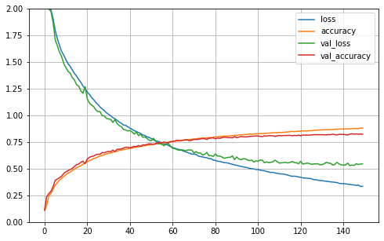

```python
# Resultats
# TODO
pd.DataFrame(history.history).plot(figsize=(8, 5))
plt.grid(True)
plt.gca().set_ylim(0, 2) # set the vertical range to [0-1]
plt.show()
```

```python
model.evaluate(X_test, y_test)
```

```
[0.5459221005439758, 0.8220000267028809]
```

## 5. Comparativa dels models implementats i predicció [1,5 punts]

En aquest darrer apartat compararem els models implementats i farem la classificació d'algunes imatges amb el model que ha donat els millors resultats.

### 5.1 Comparativa dels models implementats

**Exercici [0,5 pts.]:** Realitzar una comparativa dels models implementats comentant: * La precisió obtinguda * La pèrdua * El temps d'entrenament * El nombre de paràmetres a entrenar Comenteu els resultats obtinguts. En base als resultats obtinguts, quin model seleccionaríeu com el millor?

**Solució:** Per a aquest tipus de model (classificació d'imatges) hem comprovat que utilitzar una ANN no és gaire bona opció. El temps d'entrenament no és molt alt, però s'aconsegueixen uns resultats molt mediocres. Amb la CNN d'una sola capa ja aconseguim resultats molt superiors, però és quan utilitzem maxpooling i dropout quan aconseguim els millors resultats. Específicament, aconseguim el millor resultat en l'últim model que hem creat, utilitzant la capa RGB. Tot i que utilitzem GPU, els temps d'entrenament són bastant elevats, però ho compensa el fet d'aconseguir un model que de mitjana prediu bé 8 de cada 10 imatges.

### 5.2 Anàlisi de la millor solució

**Exercici [0,5 pts.]:** Realitzar una anàlisi de les mesures estadístiques més rellevants del model seleccionat a l'apartat anterior i representeu la matriu de confusió.

Quina classe és la que millor es prediu? I la que pitjor resultats obté?

Comentar els resultats

```python
# Informe
# TODO
model.evaluate(X_test, y_test)
```

```
[0.5459221005439758, 0.8220000267028809]
```

```python
# Matriu de confusió
# TODO
yPred = np.argmax((model.predict(X_test) > 0.5).astype("int32"),axis=1)
yTest_original=np.argmax(y_test,axis=1)
yPred_probabilities = model.predict(X_test)

from sklearn.metrics import classification_report,confusion_matrix
print("Classification report \n=======================")
print(classification_report(y_true=yTest_original, y_pred=yPred))
print("Confusion matrix \n=======================")
print(confusion_matrix(y_true=yTest_original, y_pred=yPred))
```

```
Classification report
=======================
              precision    recall  f1-score   support

           0       0.54      0.89      0.67      1000
           1       0.90      0.93      0.91      1000
           2       0.86      0.64      0.74      1000
           3       0.71      0.62      0.67      1000
           4       0.82      0.76      0.79      1000
           5       0.81      0.65      0.72      1000
           6       0.87      0.89      0.88      1000
           7       0.88      0.84      0.86      1000
           8       0.94      0.88      0.91      1000
           9       0.87      0.91      0.89      1000

    accuracy                           0.80     10000
   macro avg       0.82      0.80      0.80     10000
weighted avg       0.82      0.80      0.80     10000

Confusion matrix
=======================
[[892  17  12   6   4   0   1   5  31  32]
 [ 18 930   0   1   0   0   0   0   7  44]
 [155   4 644  34  55  32  49  12   4  11]
 [136   4  26 624  40  86  45  20   4  15]
 [104   4  26  26 762  10  26  39   1   2]
 [133   2  13 130  18 652  11  34   0   7]
 [ 48   0  14  23  16   3 892   0   1   3]
 [ 67   2   8  23  30  20   2 840   1   7]
 [ 69  24   1   4   2   0   4   1 879  16]
 [ 25  49   1   5   1   0   1   3   9 906]]
```

```python
labels = {
     0: 'airplane',
     1:'automobile',
     2:'bird',
     3:'cat',
     4:'deer',
     5:'dog',
     6:'frog',
     7:'horse',
     8:'xip',
     9:'truck',
}
y_test_labels = [labels.get(item,item) for item in yTest_original]
y_pred_labels = [labels.get(item,item) for item in yPred]
```

```
{0: 'airplane', 1: 'automobile', 2: 'bird', 3: 'cat', 4: 'deer', 5: 'dog', 6: 'frog', 7: 'horse', 8: 'xip', 9: 'truck'}
```

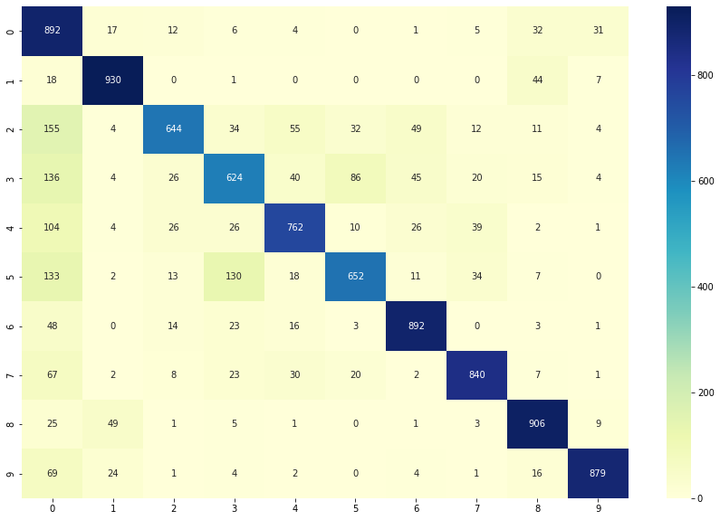

```python
import seaborn as sns
plt.figure(figsize = (15,10))
sns.heatmap(confusion_matrix(y_true=y_test_labels, y_pred=y_pred_labels), annot=True, fmt="d", cmap="YlGnBu")
print(labels)
```

### 5.3 Predicció d'algunes imatges del conjunt de test

**Exercici [0,5 pts.]:** Visualitzar deu imatges a l'atzar del conjunt de test. Mostra l'etiqueta real i la predicció.

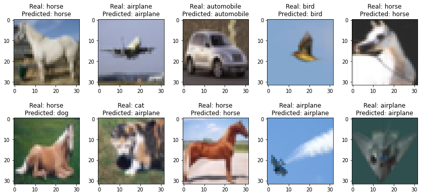

```python
# Visualització
# TODO
import random
r = list(range(len(X_test)))
random.shuffle(r)
r = r[:11]

fig, axs = plt.subplots(2,5, figsize=(15, 6), facecolor='w', edgecolor='k')
fig.subplots_adjust(hspace = .5, wspace=.001)
axs = axs.ravel()
j = 0
for i in r:
    axs[j].imshow(X_test[i])
    axs[j].set_title("Real: " + y_test_labels[i] + "\nPredicted: " + y_pred_labels[i])
    j += 1
    if j == 10:
        break
```